# Instrumente Statistice pentru Finanțe

### 4.10.2 Adăugarea elementelor textuale la grafic

Sunt multe situații (e.g. în cazul unor prezentări, rapoarte, proiecte, etc.) în care pentru a face un grafic mai expresiv/ilustrativ este necesară adăugarea de elemente textuale explicative. Aceste elemente pot fi adăugate de cele mai multe ori folosind funcțiile `geom_text`, `geom_label`, `annotate` sau funcțiile corespunzătoare din pachetul `ggrepel`. Vom prezenta mai jos câteva exeple de grafice în care adăugarea de elemente textuale facilitează înțelegerea mesajului transmis de figură.

Pentru început vom folosi un barplot orizontal în care dorim să adăugăm marcaje în dreptul fiecărei bare:

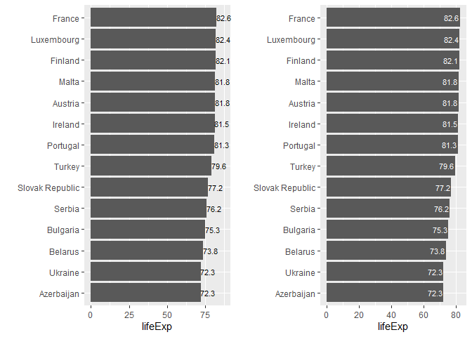

```r
set.seed(1234)

baza = gapminder_2018 %>%
  filter(continent == "Europe") %>%
  sample_frac(0.3) %>%
  ggplot(aes(x = fct_reorder(country, lifeExp), y = lifeExp)) +
  geom_bar(stat = "identity") +
  coord_flip() +
  labs(x = "")

baza +
  geom_text(aes(label = lifeExp),
            size = 3, nudge_y = 5)

baza +
  geom_text(aes(label = lifeExp), size = 3,
            nudge_y = - 5, color = "white")
```

În cazul în care dorim să atragem atenția doar asupra unei bare atunci:

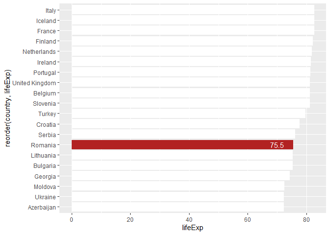

```r
countries = c("Moldova", "Georgia", "Italy", "Croatia", "Slovenia",
              "Ukraine", "Azerbaijan", "Romania", "Turkey", "Macedonia",
              "Belgium", "France", "Finland", "Iceland", "Netherlands",
              "Lithuania", "Serbia", "Portugal", "Ireland", "Bulgaria",
              "United Kingdom")

baza_gap = gapminder_2018 %>%
  filter(country %in% countries) %>%
  mutate(ID = ifelse(country == "Romania", TRUE, FALSE))

ggplot(baza_gap, aes(x = reorder(country, lifeExp), y = lifeExp, fill = ID)) +
        geom_bar(stat = "identity") +
        coord_flip() +
        scale_fill_manual(values = c("white", "firebrick"),
                          guide = FALSE) +
        annotate("text", x = "Romania", y = 70, label = "75.5", color = "white")
```

Pentru a adăuga etichete la o diagramă cu bare proporțională (pentru care avem ajustată poziția la `fill`) trebuie să creăm o nouă variabilă care să stocheze locația (suma cumulativă a proporțiilor):

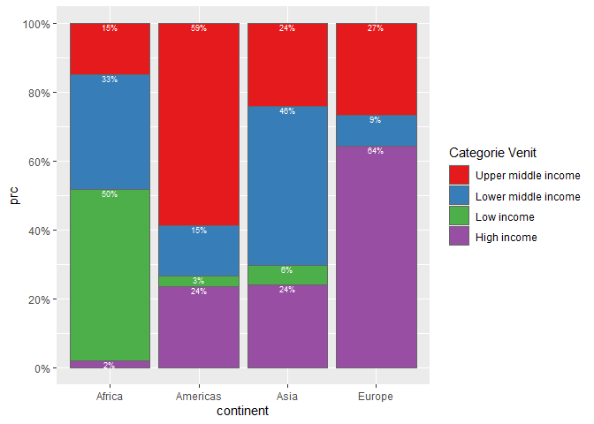

```r
# pregatim setul de date
gapminder_2018_bf = gapminder_2018 %>%
  group_by(continent, wb_income) %>%
  # cate elemente am din fiecare wb_income pentru
  # fiecare continent in parte
  tally() %>%
  # grupez dupa continent
  group_by(continent) %>%
  # determin proportia
  mutate(prc = n / sum(n),
         label_y = cumsum(prc))


gapminder_2018_bf %>%
  ggplot(aes(x = continent, y = prc, fill = fct_rev(wb_income))) +
  geom_bar(stat = "identity", color = "grey40") +
  scale_y_continuous(breaks = seq(0, 1, by = .2), labels = scales::percent) +
  geom_text(aes(label = scales::percent(prc), y = label_y),
            vjust = 1, color = "white", size = 2.5) +
  scale_fill_manual(values = c("#E41A1C", "#377EB8", "#4DAF4A", "#984EA3")) +
  labs(fill = "Categorie Venit")
```

### 4.10.3 Teme grafice

Putem schimba întregul aspect al graficului prin modificarea *temei* (funcția `theme()`) acestuia. Temele reprezintă o modalitate consistentă de a customiza/personaliza elementele grafice ale unei figuri, elemente care nu fac referire la setul de date (titlu, etichetele axelor, mărimea și tipul fontului, culoarea de fundal, liniile de marcaj - gridlines, legendele, etc.).

Pentru a utiliza o temă trebuie să adăugăm unui obiect de tip `ggplot` o funcție de temă care are forma generală `theme_<nume temă>`. Pachetul `ggplot2` vine cu o serie de teme predefinite printre care menționăm: `theme_grey`, `theme_linedraw`, `theme_bw`, `theme_minimal`, `theme_void`, `theme_dark`, `theme_classic`, `theme_light`. Figura de mai jos prezintă fiecare dintre aceste teme pentru setul de date `gapminder_2018`:

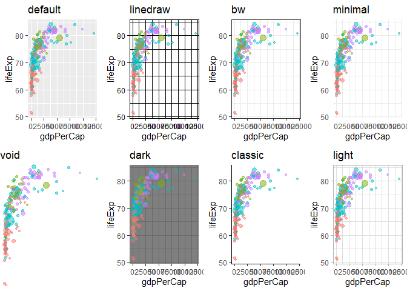

Ilustrare a temelor predefinite

Pe lângă temele predefinite în `ggplot2` se pot folosi și teme din pachetul `ggthemes` dezvoltat de Jeffrey Arnold (pentru mai multe detalii vizitați site-ul [ggthemes](https://jrnold.github.io/ggthemes/reference/index.html)) care cuprinde mai mult de 20 de astfel de teme unele fiind reprezentări fidele ale tematicilor grafice folosite de reviste sau programe consacrate (de exemplu *Economist* sau *Excel*). Mai jos sunt prezentate doar patru dintre acestea:

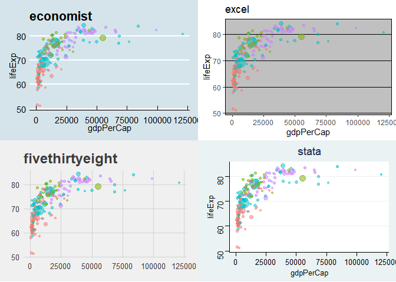

Ilustrare a temelor din pachetul ggthemes

Pentru a modifica elementele unei temei vom folosi funcția `theme()`. Această funcție ne permite controlul (aproape total) asupra elementelor grafice care nu țin de setul de date dar prin intermediul cărora figura devine mai expresivă: marimea fontului, culoarea de fundal, fontul și culoarea etichetelor axelor și ale legendei, etc.

Structura generală este `theme([element al temei] = element_[nume functie asociată]([proprietati schimbate]))` unde

- `[element al temei]` face referire la un element grafic precum `plot.title` (controleaza modul de afișare a titlului graficului), `axis.ticks.x` (elemente de marcaj de pe axa x), `legend.key.height` (înălțimea elementelor din legendă) etc. Pentru a vizualiza toate elementele grafice ale unei teme ce pot fi modificate se poate consulta documentația https://ggplot2.tidyverse.org/reference/theme.html
- `element_[nume functie asociată]` reprezintă o funcție asociată elementelor temei care descrie caracteristicile vizuale ale elementului (toate elementele au asociate o astfel de funcție). Sunt patru astfel de funcții: `element_text`, `element_line`, `element_rect` și `element_blank`.
- `[proprietati schimbate]` reprezintă caracteristicile vizuale ce urmează să fie modificate, i.e. `font`, `family`, `linetype`, `colour`, `size`, etc.

Tabelul de mai jos prezintă o serie de caracteristici vizuale pentru fiecare funcție asociată elementelor unei teme grafice:

| Funcție | Caracteristici |
| --- | --- |
| `element_text()` | `family`, `face`, `colour`, `size` (în points), `hjust`, `vjust`, `angle` (în grade), `lineheight` |
| `element_line()` | `colour`, `size`, `linetype`, `lineend` |
| `element_rect()` | `fill`, `colour`, `size`, `linetype` |
| `element_blank()` |  |

Exemple:

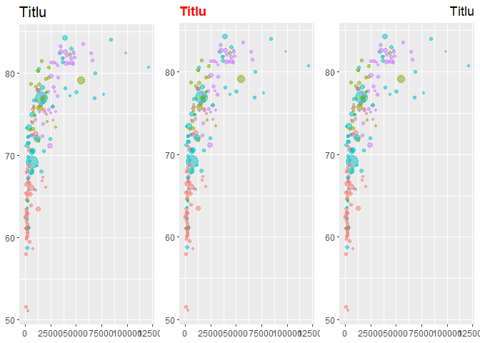

```r
baza = ggplot(gapminder_2018) +
  geom_point(aes(x = gdpPerCap, y = lifeExp, color = continent, size = pop),
             alpha = 0.5, show.legend = FALSE)

baza <- baza + labs(title = "Titlu") + xlab(NULL) + ylab(NULL)
baza + theme(plot.title = element_text(size = 16))
baza + theme(plot.title = element_text(face = "bold", colour = "red"))
baza + theme(plot.title = element_text(hjust = 1))
```

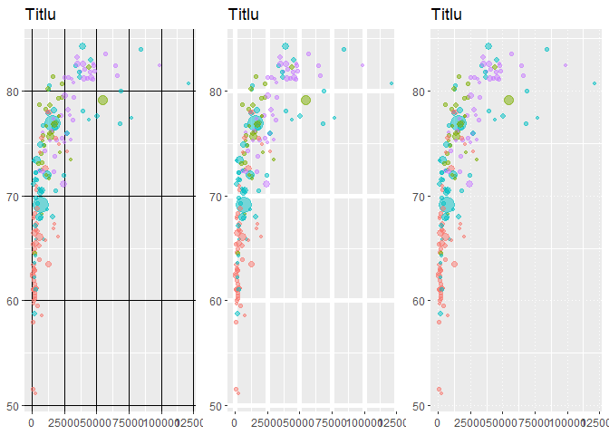

```r
baza + theme(panel.grid.major = element_line(colour = "black"))
baza + theme(panel.grid.major = element_line(size = 2))
baza + theme(panel.grid.major = element_line(linetype = "dotted"))
```

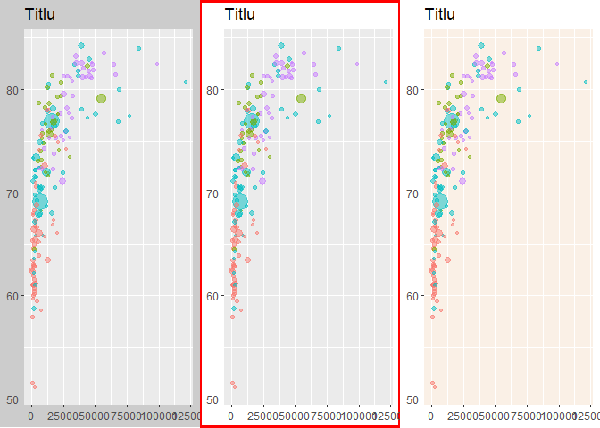

```r
baza + theme(plot.background = element_rect(fill = "grey80", colour = NA))
baza + theme(plot.background = element_rect(colour = "red", size = 2))
baza + theme(panel.background = element_rect(fill = "linen"))
```

Mai jos regăsim o serie de elemente care permit controlul vizual al axelor și legendelor împreună cu funcțiile asociate acestora:

| Obiect | Element | Setter | Description |
| --- | --- | --- | --- |
| axe | axis.line | `element_line()` | drepte paralele cu axele (nu se văd implicit) |
|  | axis.text | `element_text()` | etichetele axelor (x și y) |
|  | axis.text.x | `element_text()` | etichetele axei x |
|  | axis.text.y | `element_text()` | etichetele axei y |
|  | axis.title | `element_text()` | titlurile axelor |
|  | axis.title.x | `element_text()` | tiltlul axei x |
|  | axis.title.y | `element_text()` | tiltlul axei y |
|  | axis.ticks | `element_line()` | elementele de marcaj ale axelor |
|  | axis.ticks.length | `unit()` | lungimea elementelor de marcaj |
| legendă | legend.background | `element_rect()` | fundalul legendei |
|  | legend.key | `element_rect()` | fundalul elementelor legendei |
|  | legend.key.size | `unit()` | marimea elementelor legendei |
|  | legend.key.height | `unit()` | înălțimea elementelor legendei |
|  | legend.key.width | `unit()` | lățimea elementelor legendei |
|  | legend.margin | `unit()` | marginile legendei |
|  | legend.text | `element_text()` | etichetele legendei |
|  | legend.text.align | 0–1 | alinierea etichetelor legendei (0 = dreapta, 1 = stânga) |
|  | legend.title | `element_text()` | titlul legendei |
|  | legend.title.align | 0–1 | alinierea titlului legendei (0 = dreapta, 1 = stânga) |

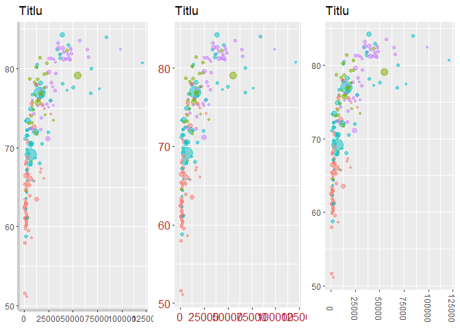

```r
baza + theme(axis.line = element_line(colour = "grey80", size = 1.5))
baza + theme(axis.text = element_text(color = "firebrick", size = 12))
baza + theme(axis.text.x = element_text(angle = -90, vjust = 0.5))
```

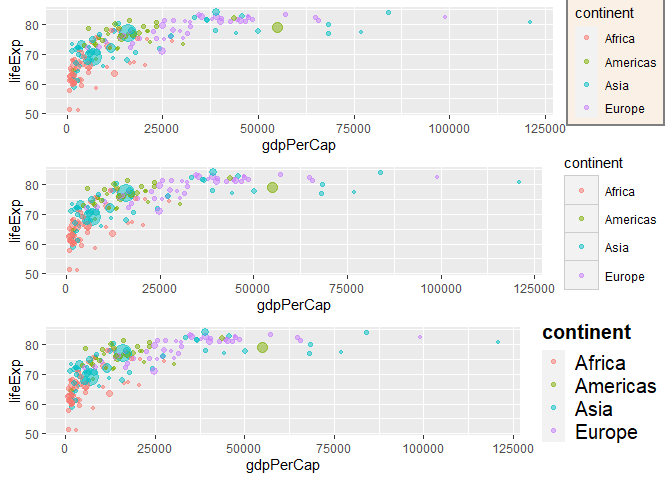

```r
baza2 = ggplot(gapminder_2018) +
  geom_point(aes(x = gdpPerCap, y = lifeExp, color = continent, size = pop),
             alpha = 0.5) +
  guides(size = "none")

baza2 + theme(
  legend.background = element_rect(
    fill = "linen",
    colour = "grey50",
    size = 1
  )
)
baza2 + theme(
  legend.key = element_rect(color = "grey80"),
  legend.key.width = unit(0.9, "cm"),
  legend.key.height = unit(0.75, "cm")
)
baza2 + theme(
  legend.text = element_text(size = 15),
  legend.title = element_text(size = 15, face = "bold")
)
```

Pentru a mai multe detalii și exemple privind elementele grafice ale unei teme ce pot fi modificate se poate consulta documentația https://ggplot2.tidyverse.org/reference/theme.html.

## 4.11 Exemple folosind setul de date `gapminder`

Noțiunile prezentate în acest capitol, puse cap la cap, permit generarea figurii de la începutul capitolului. Mai jos este prezentat codul folosit pentru generarea figurii (pentru anul 2018):

```r
ggplot(gapminder_2018) +
  # adaugam curba de regresie loess
  geom_smooth(aes(x = gdpPerCap, y = lifeExp),
              se = FALSE, method = "loess",
              color = "orange", size = 0.7, alpha = 0.7) +
  # adaugam puncte fara Romania
  geom_point(data = gapminder_2018 %>% filter(country != "Romania"),
             aes(x = gdpPerCap, y = lifeExp, color = continent, size = pop),
             alpha = 0.5) +
  # adaugam Romania si o facem de forma diferita - cerc gol
  geom_point(data = gapminder_2018 %>% filter(country == "Romania"),
             aes(x = gdpPerCap, y = lifeExp, color = continent, size = pop),
             shape = 1,
             stroke = 1.5)+
  # adaugam text pentru o serie de state (ggrepel)
  geom_text_repel(aes(x = gdpPerCap, y = lifeExp, label = country),
            color = "grey50",
            segment.size = 0.2,
            data = gapminder_2018 %>%
              filter(pop > 1e9 | country %in% c("Moldova",
                                                "United States",
                                                "Romania",
                                                "United Kingdom",
                                                "France"))) +
  # schimbam scala pe x in scala logaritmica
  scale_x_log10(limits = c(600, 75000),
                breaks = c(600, 1000, 2500, 5000, 10000,
                           25000, 50000, 75000),
                label = scales::dollar_format(prefix = "", suffix = "$", accuracy = 1)) +
  # adaugam ani la scala de pe y
  scale_y_continuous(label = function(x) {return(paste(x, "ani"))}) +
  # schimbam etichetele si adaugam titlu
  labs(title = "GDP versus Speranta de  viata in 2018",
       caption = "Sursa: https://www.gapminder.org/",
       x = "GDP per capita (scala log)",
       y = "Speranta medie de viata",
       size = "Populatia",
       color = "Continent") +
  # schimbam marimea scalei
  scale_size(range = c(0.1, 10),
             # stergem legenda pentru size
             guide = "none") +
  # adaugam culori customizate pentru continente
  scale_color_manual(name = "",
                     values = c("#099DD7",
                                "#248E84",
                                "#F2583F",
                                "#96503F"),
                     guide = guide_legend(nrow = 1, order=1)) +
  # schimbam tema
  theme_minimal() +
  # plasam legenda sus si scoatem gridul
  theme(legend.position = "top",
        axis.line = element_line(color = "grey85"),
        axis.ticks = element_line(color = "grey85"),
        panel.grid.major = element_blank(),
        panel.grid.minor = element_blank())
```

Cu un pic mai mult efort se poate construi figura de mai jos care în plus evidențiază pentru fiecare continent în parte tendința (dreapta de regresie) corespunzătoare:

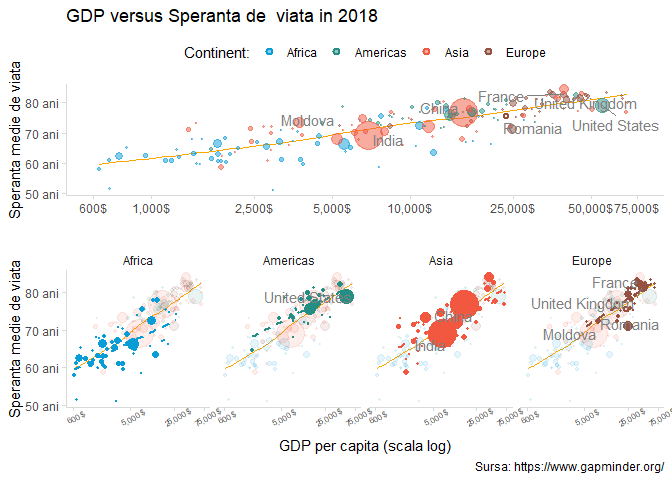

```r
countries = c("Romania", "France", "Germany", "United Kingdom", "Italy", "Greece",
              "United States", "Canada", "Brazil", "Mexico",
              "China", "India", "Vietnam",
              "Ethiopia", "South Africa", "Nigeria",
              "Australia", "New Zealand")

gapminder_life_exp_diff <- gapminder_all %>%
  mutate(year = as.integer(year),
         continent = four_regions) %>%
  # filtram anii de start si de final
  filter(year == 2000 | year == 2018) %>%
  # ne asiguram ca datele sunt aranjate astfel ca anul 2000 sa fie inaintea lui 2018
  arrange(country, year) %>%
  # pentru fiecare tara adaugam variabila care ne da diferenta sperantei de viata
  group_by(country) %>%
  mutate(lifeExp_diff = lifeExp[2] - lifeExp[1]) %>%
  ungroup() %>%
  # aranjam in ordinea diferentelor cele mai mari
  arrange(lifeExp_diff) %>%
  # restrangem la tarile selectate
  filter(country %in% countries) %>%
  select(country, year, continent, lifeExp, lifeExp_diff)


gapminder_life_exp_diff %>%
  mutate(country = fct_inorder(country)) %>%
  # pentru fiecare tara definim minimul si maximul sperantei de viata
  group_by(country) %>%
  mutate(max_lifeExp = max(lifeExp),
         min_lifeExp = min(lifeExp)) %>%
  ungroup() %>%
  ggplot() +
  # trasam segmentele
  geom_segment(aes(x = min_lifeExp, xend = max_lifeExp,
                   y = country, yend = country,
                   col = continent), alpha = 0.5, size = 5) +
  # adaugam punctele de capat
  geom_point(aes(x = lifeExp, y = country, col = continent), size = 8,
             shape = 21, fill = "white", stroke = 2) +
  # adaugam elementele textuale
  geom_text(aes(x = min_lifeExp + 0.47, y = country,
                label = paste(country, " ", round(min_lifeExp))),
            col = "grey50", hjust = "right") +
  geom_text(aes(x = max_lifeExp - 0.4, y = country,
                label = round(max_lifeExp)),
            col = "grey50", hjust = "left") +
  # delimitam axa x
  scale_x_continuous(limits = c(45, 85)) +
  # alegem culorile
  scale_color_manual(values = c("#099DD7",
                                "#248E84",
                                "#F2583F",
                                "#96503F")) +
  # stabilim titlul si axele
  labs(title = "Schimbarea speranței de viață",
       subtitle = "Între anii 2000 și 2018",
       x = "Speranța de viață (în 2000 și 2018)",
       y = NULL,
       col = "Continent: ") +
  # folosim tema clasica
  theme_classic() +
  # eliminam axele si pozitionam legenda
  theme(legend.position = "top",
        axis.line = element_blank(),
        axis.ticks = element_blank(),
        axis.text = element_blank())
```

[output not shown]

Mai mult dacă dorim să ilustrăm evoluția speranței de viață în Europa evidențiind pentru fiecare țară în parte parcurul atunci putem obține un grafic de forma

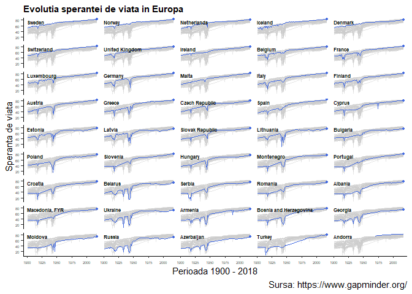

Evolutia sperantei de viata in Europa dupa anul 1900

```r
# setul de background
gap_bg = gapminder_all %>%
  mutate(continent = four_regions,
         year = as.integer(year)) %>%
  filter(continent == "Europe",
         year > 1900) %>%
  rename(country2 = country)

# capetele
gap_bg_endpoints = gap_bg %>%
  filter(year == 2018) %>%
  rename(country = country2)

## tarile
gap_bg_countries = gap_bg %>%
  group_by(country2) %>%
  filter(year == min(year)) %>%
  ungroup() %>%
  mutate(year = 1900,
         country = country2,
         lifeExp = max(gap_bg$lifeExp, na.rm = TRUE) - 2)

# constructia graficului
gapminder_all %>%
  mutate(continent = four_regions,
         year = as.integer(year)) %>%
  filter(continent == "Europe",
         year > 1900) %>%
ggplot(aes(x = year, y = lifeExp)) +
  # trasarea curbelore de background
  geom_line(data = gap_bg,
            aes(x = year, y = lifeExp, group = country2),
            size = 0.15, color = "gray80", alpha = 0.5)+
  # trasarea liniilor evidentiate
  geom_line(aes(group = country),
            color = "royalblue",
            lineend = "round") +
  # adaugarea punctelor la final
  geom_point(data = gap_bg_endpoints,
             aes(x = year, y = lifeExp),
             size = 1.1,
             shape = 21,
             color = "royalblue",
             fill = "royalblue") +
  # adaugarea tarilor - stanga sus
  geom_text(data = gap_bg_countries,
            mapping = aes(label = country),
            vjust = "inward",
            hjust = "inward",
            fontface = "bold",
            size = 2.1) +
  # fatetarea dupa country reordonat
  facet_wrap(~ reorder(country, - lifeExp), ncol = 5)+
  # redenumirea axelor
  labs(x = "Perioada 1900 - 2018",
       y = "Speranta de viata",
       title = "Evolutia sperantei de viata in Europa",
       caption = "Sursa: https://www.gapminder.org/") +
  # customizarea temei
  theme_classic()+
  theme(plot.title = element_text(size = rel(1), face = "bold"),
        plot.caption = element_text(size = rel(1)),
        # scoatem titlurile fatetelor
        strip.text = element_blank(),
        panel.spacing.x = unit(-0.05, "lines"),
        panel.spacing.y = unit(0.3, "lines"),
        axis.text.y = element_text(size = rel(0.5)),
        axis.title.x = element_text(size = rel(1)),
        axis.title.y = element_text(size = rel(1)),
        axis.text.x = element_text(size = rel(0.5)),
        legend.text = element_text(size = rel(1)))
```

Atunci când dorim să salvăm un grafic putem folosi funcția `ggsave()` care prin comportamentul de bază salvează ultimul grafic generat. Funcția permite specificarea graficului pe care dorim să îl salvăm (`plot =`), locația și numele fișierului salvat (`filename =`), dimensiunea (`width =`, `height =`) precum și tipul acestuia (`png`, `jpeg`, `tiff`, `pdf`, `tex`, etc.).

De exemplu, pentru a salva figura generată de codul de mai sus (figura de la începutul capitolului) într-un fișier *pdf* în format *landscape* putem scrie

```r
ggsave(filename = "grafic.pdf",
       width = 11, height = 8.5)
```

ținând cont că acesta este ultimul grafic generat, în caz contrar trebuie să specificăm pe care grafic dorim să îl salvăm. Astfel, dacă figura este atribuită elementului `p` (`p = ggplot(gapminder_2018) + ...`) atunci pentru a salva scriem

```r
ggsave(filename = "grafic.pdf",
       plot = p,
       width = 11, height = 8.5)
```

Încercați să recreați grafice similare cu cel de la începutul capitolului (sau cel de mai sus) pentru alte seturi de date ce pot fi descărcate de pe platforma www.gapminder.org/data/.

# Referințe

Robbins, Naomi. 2013. *Creating More Effective Graphs*. First. New York, NY: Chart House.

Wickham, Hadley. 2014. “Tidy Data.” *Journal of Statistical Software, Articles* 59 (10): 1–23. https://doi.org/10.18637/jss.v059.i10.

———. 2016. *Ggplot2: Elegant Graphics for Data Analysis*. Springer-Verlag New York. https://ggplot2.tidyverse.org.

Wickham, Hadley, Romain François, Lionel Henry, Kirill Müller, and R Studio. 2019. “Dplyr: A Grammar of Data Manipulation Ver. 0.8.3.”

Wickham, Hadley, and Garrett Grolemund. 2017. *R for Data Science: Import, Tidy, Transform, Visualize, and Model Data*. 1st ed. O’Reilly Media, Inc.

Wickham, Hadley, and Lionel Henry. 2020. *Tidyr: Tidy Messy Data*. https://CRAN.R-project.org/package=tidyr.

Wilkinson, Leland. 2005. *The Grammar of Graphics (Statistics and Computing)*. First. Secaucus, NJ: Springer-Verlag.